# WHITE WINE DATASET EDA by OLGA DERNOVSKA

In the beginning of the project, before starting our analysis, let’s take a look at our dataset to see its structure, brief view of the dataset and general statistics for each variable.

```
## 'data.frame':    4898 obs. of  13 variables:
##  $ X                   : int  1 2 3 4 5 6 7 8 9 10 ...
##  $ fixed.acidity       : num  7 6.3 8.1 7.2 7.2 8.1 6.2 7 6.3 8.1 ...
##  $ volatile.acidity    : num  0.27 0.3 0.28 0.23 0.23 0.28 0.32 0.27 0.3 0.22 ...
##  $ citric.acid         : num  0.36 0.34 0.4 0.32 0.32 0.4 0.16 0.36 0.34 0.43 ...
##  $ residual.sugar      : num  20.7 1.6 6.9 8.5 8.5 6.9 7 20.7 1.6 1.5 ...
##  $ chlorides           : num  0.045 0.049 0.05 0.058 0.058 0.05 0.045 0.045 0.049 0.044 ...
##  $ free.sulfur.dioxide : num  45 14 30 47 47 30 30 45 14 28 ...
##  $ total.sulfur.dioxide: num  170 132 97 186 186 97 136 170 132 129 ...
##  $ density             : num  1.001 0.994 0.995 0.996 0.996 ...
##  $ pH                  : num  3 3.3 3.26 3.19 3.19 3.26 3.18 3 3.3 3.22 ...
##  $ sulphates           : num  0.45 0.49 0.44 0.4 0.4 0.44 0.47 0.45 0.49 0.45 ...
##  $ alcohol             : num  8.8 9.5 10.1 9.9 9.9 10.1 9.6 8.8 9.5 11 ...
##  $ quality             : int  6 6 6 6 6 6 6 6 6 6 ...
```

```
##   X fixed.acidity volatile.acidity citric.acid residual.sugar chlorides
## 1 1           7.0             0.27        0.36           20.7     0.045
## 2 2           6.3             0.30        0.34            1.6     0.049
## 3 3           8.1             0.28        0.40            6.9     0.050
## 4 4           7.2             0.23        0.32            8.5     0.058
## 5 5           7.2             0.23        0.32            8.5     0.058
## 6 6           8.1             0.28        0.40            6.9     0.050
##   free.sulfur.dioxide total.sulfur.dioxide density   pH sulphates alcohol
## 1                  45                  170  1.0010 3.00      0.45     8.8
## 2                  14                  132  0.9940 3.30      0.49     9.5
## 3                  30                   97  0.9951 3.26      0.44    10.1
## 4                  47                  186  0.9956 3.19      0.40     9.9
## 5                  47                  186  0.9956 3.19      0.40     9.9
## 6                  30                   97  0.9951 3.26      0.44    10.1
##   quality
## 1       6
## 2       6
## 3       6
## 4       6
## 5       6
## 6       6
```

```
##        X        fixed.acidity    volatile.acidity  citric.acid
##  Min.   :   1   Min.   : 3.800   Min.   :0.0800   Min.   :0.0000
##  1st Qu.:1225   1st Qu.: 6.300   1st Qu.:0.2100   1st Qu.:0.2700
##  Median :2450   Median : 6.800   Median :0.2600   Median :0.3200
##  Mean   :2450   Mean   : 6.855   Mean   :0.2782   Mean   :0.3342
##  3rd Qu.:3674   3rd Qu.: 7.300   3rd Qu.:0.3200   3rd Qu.:0.3900
##  Max.   :4898   Max.   :14.200   Max.   :1.1000   Max.   :1.6600
##  residual.sugar     chlorides       free.sulfur.dioxide
##  Min.   : 0.600   Min.   :0.00900   Min.   :  2.00
##  1st Qu.: 1.700   1st Qu.:0.03600   1st Qu.: 23.00
##  Median : 5.200   Median :0.04300   Median : 34.00
##  Mean   : 6.391   Mean   :0.04577   Mean   : 35.31
##  3rd Qu.: 9.900   3rd Qu.:0.05000   3rd Qu.: 46.00
##  Max.   :65.800   Max.   :0.34600   Max.   :289.00
##  total.sulfur.dioxide    density             pH          sulphates
##  Min.   :  9.0        Min.   :0.9871   Min.   :2.720   Min.   :0.2200
##  1st Qu.:108.0        1st Qu.:0.9917   1st Qu.:3.090   1st Qu.:0.4100
##  Median :134.0        Median :0.9937   Median :3.180   Median :0.4700
##  Mean   :138.4        Mean   :0.9940   Mean   :3.188   Mean   :0.4898
##  3rd Qu.:167.0        3rd Qu.:0.9961   3rd Qu.:3.280   3rd Qu.:0.5500
##  Max.   :440.0        Max.   :1.0390   Max.   :3.820   Max.   :1.0800
##     alcohol         quality
##  Min.   : 8.00   Min.   :3.000
##  1st Qu.: 9.50   1st Qu.:5.000
##  Median :10.40   Median :6.000
##  Mean   :10.51   Mean   :5.878
##  3rd Qu.:11.40   3rd Qu.:6.000
##  Max.   :14.20   Max.   :9.000
```

**General information about dataset** The dataset is related to white variants of the Portuguese “Vinho Verde” wine.

Input variables. Fixed acidity (tartaric acid - g / dm^3): most acids involved with wine or fixed or nonvolatile

Volatile acidity (acetic acid - g / dm^3): the amount of acetic acid in wine, which at too high of levels can lead to an unpleasant, vinegar taste. In our dataset we have range from 0.08 to 1.1 with 50% of wines to be in range 0.21 to 0.32

Citric acid (g / dm^3): found in small quantities, citric acid can add ‘freshness’ and flavor to wines. In our dataset we have range from 0 to 1.66.

Residual sugar (g / dm^3): the amount of sugar remaining after fermentation stops, it’s rare to find wines with less than 1 gram/liter. Wines with greater than 45 grams/liter are considered sweet. In our dataset we have range from 0.6 to 65.8. We can explore this variable in details.

Chlorides (sodium chloride - g / dm^3): the amount of salt in the wine

Free sulfur dioxide (mg / dm^3): it prevents microbial growth and the oxidation of wine

Total sulfur dioxide (mg / dm^3): amount of free and bound forms of S02; in low concentrations, SO2 is mostly undetectable in wine, but at free SO2 concentrations over 50 ppm, SO2 becomes evident in the nose and taste of wine. In our dataset we have range from 9 to 440, which is much higher than 50, so we can explore this variable.

Density (g / cm^3): is close to that of water depending on the percent alcohol and sugar content In our dataset we have range from 0.9871 to 1.0390. Indeed, it is close to the density of water (1.0)

PH: describes how acidic or basic a wine is on a scale from 0 (very acidic) to 14 (very basic); most wines are between 3-4 on the pH scale In our dataset we have range from 2.72 to 3.82, which is really close and most probably will have no difference.

Sulphates (potassium sulphate - g / dm3): a wine additive which can contribute to sulfur dioxide gas (S02) levels, which acts as an antimicrobial and antioxidant. In our dataset we have range from 0.22 to 1.08

Alcohol: the percent alcohol content of the wine In our dataset we have range from 8.0 to 14.2 It is rather wide range for wine, so we can explore this variable in details.

Output variable: Quality (score between 0 and 10) In our dataset we have range from 3 to 9 with 50% of observations to lay between 5 and 6.

# Univariate Plots Section

#### Explore distribution of quality

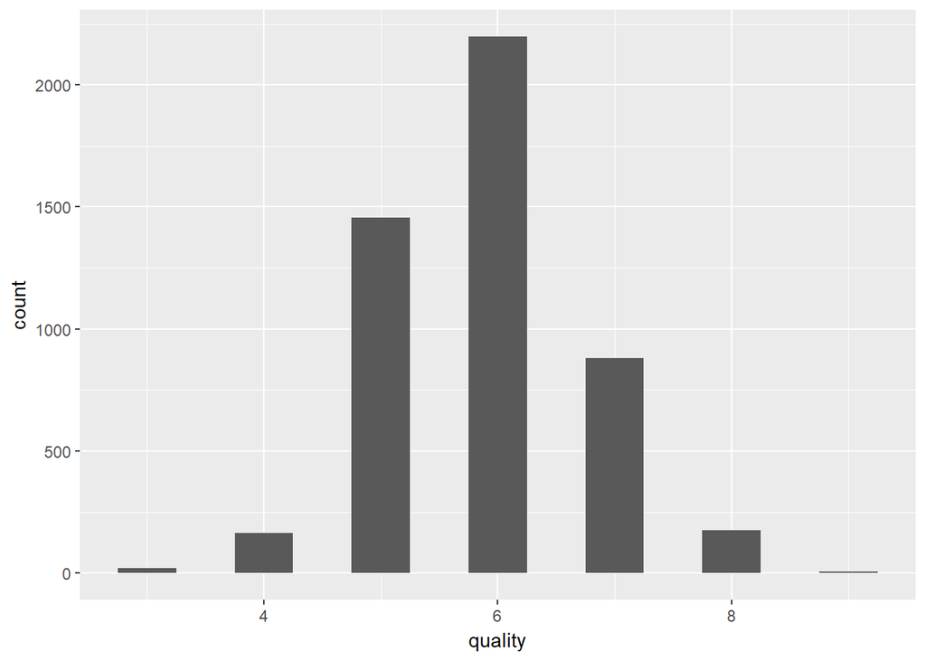

We can see that most of our wines (about 50%) have quality 6, many wines are 5 and 7, few wines are 3, 4, 8 and 9. Quality is a discrete variable, but we can see its distribution is close to normal, there are no outliers and no gaps in the distribution, but poor and high quality wines are few.

#### Explore distribution of residual sugar - sweetness of wine

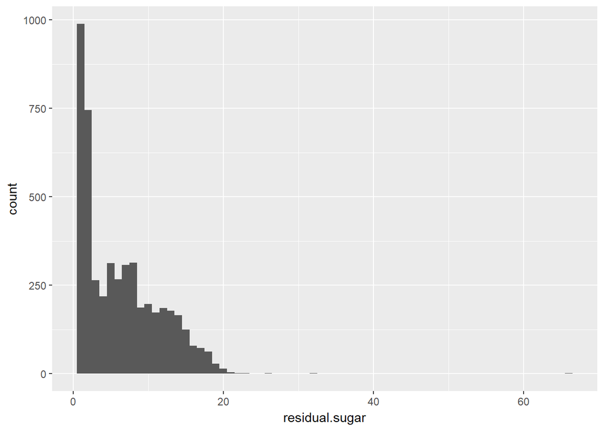

The distribution of residual sugar is right-skewed, with most of the values to be under 20. Values which are more than 20 are few. Let’s take a look at them closely:

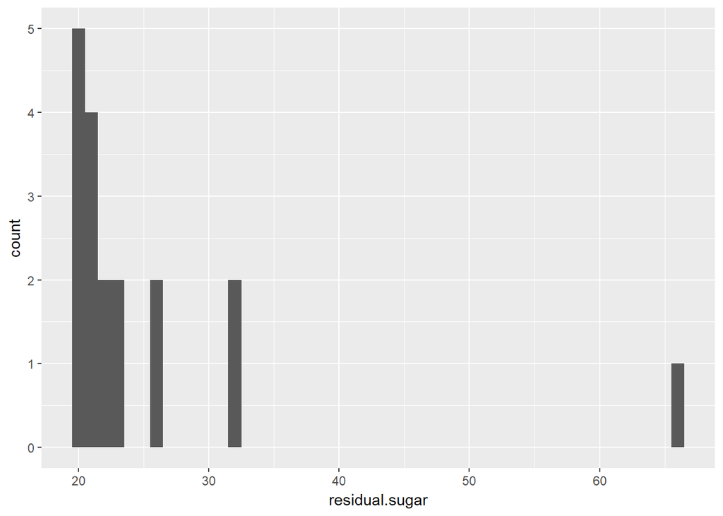

There is only one wine with sugar content around 66, all others are under 33. This observation is an outlier, and I will remove it from my dataset.

```
## [1] 4897   13
```

As we can see, now there are 4897 observations in our dataset.

Now we can group our wines into categories depending on residual sugar. According to EU regulation 753/2002, the following terms may be used on the labels of table wines and quality wines: Dry - up to 4 g/l, if balanced with suitable acidity - up to 9 g/l Medium Dry - up to 12 g/l, if balanced with suitable acidity - up to 18 g/l Medium- up to 45 g/l Sweet - more than 45 g/l Let’s consider, that our wines are balanced, and use levels 9 g/l and 18 g/l for groupping the wines. New variable will take the name ‘category’.

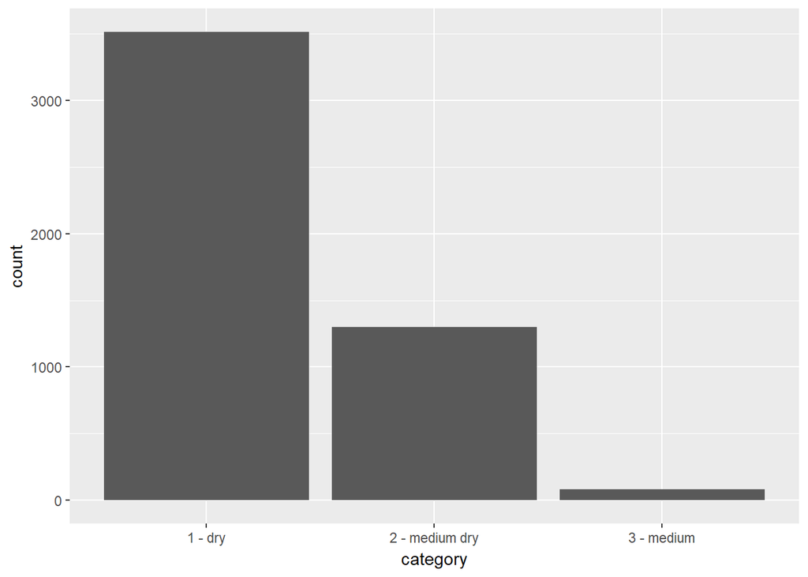

As mentioned before, most of the wines are dry, and it is normal for south-european wines.

#### Explore alcohol content distribution

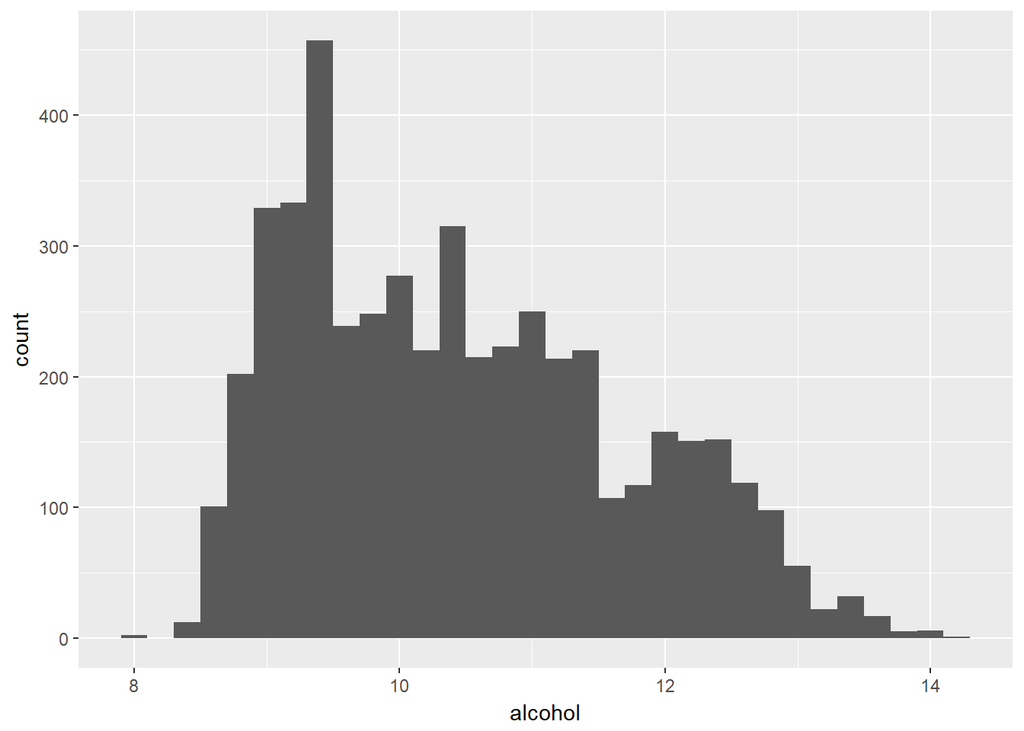

The distribution of alcohol is slightly right skewed, without long tail, but with big difference on the left side. In the beginning of the x-scale there are only few observations, then a gap, then again only few, and then bins are high with 100, 200 and more observations. This abrupt end can possible have influence for our visualizations, so we need to keep it in mind in future explorations. From the other side, I would not like to delete it as it is not an outlier, and it’s value is normal for wines.

#### Explore pH distribution

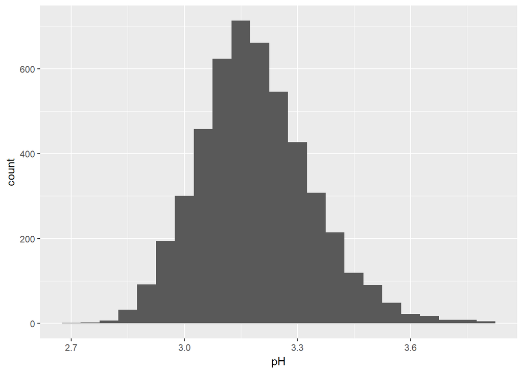

PH is normally distributed, its range is narrow and very common for wines, so we can consider that all our wine has normal pH levels and won’t explore it deeper.

#### Explore volatile acidity distribution

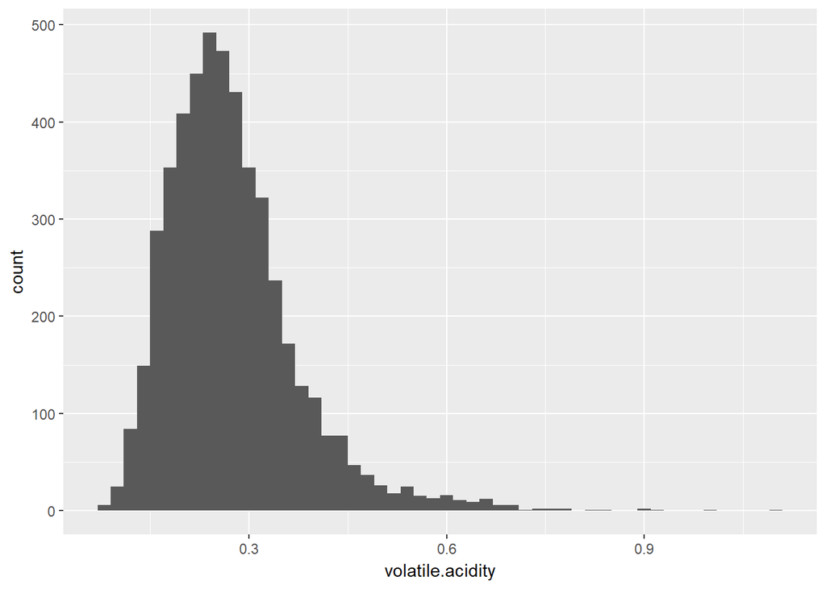

Distribution of volatile acidity is slightly right-skewed. We could say, that it is normally distributed till approx. 0.5 and then has a tail. It happens to be range of 0.6 to 0.9 of volatile acidity, which the human threshold can detect. Volatile acidity imparts a racy, balsamic edge to a wine. I will explore the impact of this variable on quality in later analysis.

#### Explore total sulfur dioxide distribution

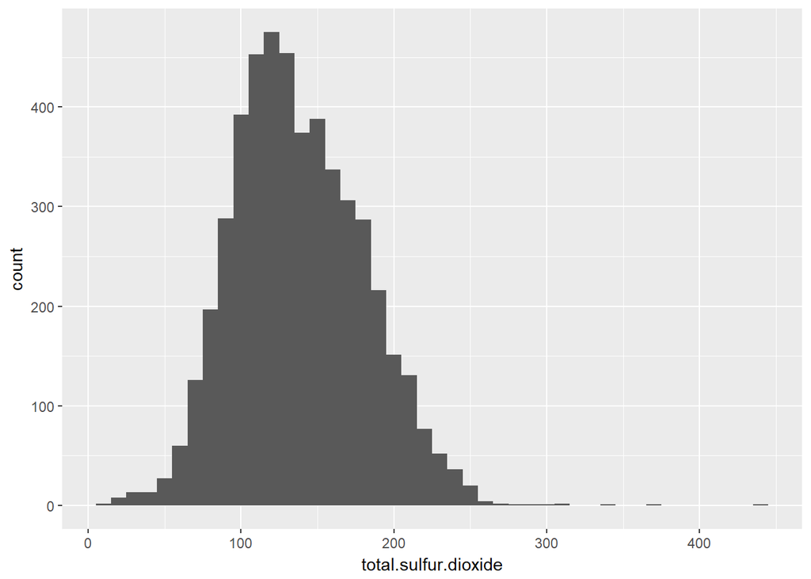

We can see normal distribution for this variable. In later analysis we will check if it has any influence on the quality.

#### Explore density distribution

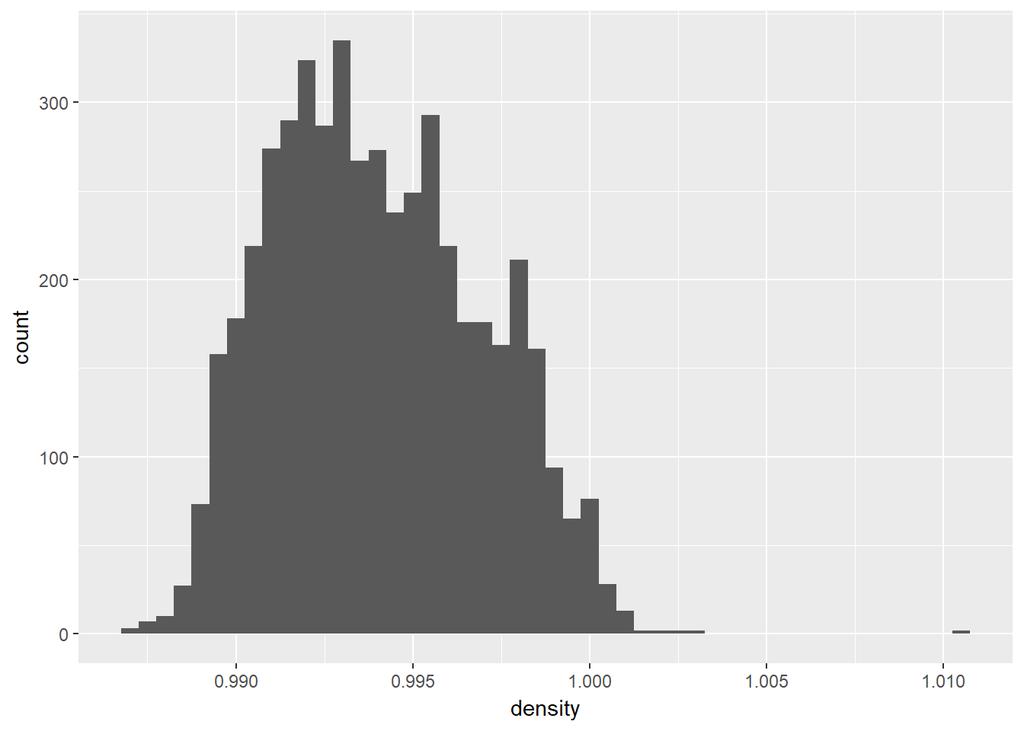

We can see normal distribution of this variable.

# Univariate Analysis

### What is/are the main feature(s) of interest in your dataset?

The main features of interest for me are alcohol and residual sugar, if they are corellated and their influence on quality

### What other features in the dataset do you think will help support your investigation into your feature(s) of interest?

I would like to see also the input from volatile acidity and density.

### Did you create any new variables from existing variables in the dataset?

I created new categorical variable ‘category’ depending on the residual sugar content. I used wine classification for labeling wines as dry, medium dry and medium.

### Of the features you investigated, were there any unusual distributions? Did you perform any operations on the data to tidy, adjust, or change the form of the data? If so, why did you do this?

I noticed, that the distribution of residual sugar was long-tailed. There was one outlier, which value was very far from all the other values and would influence our explorations. This outlier was deleted from the dataset.

# Bivariate Plots Section

Let’s take a quick look at the correlation between all the variables in our dataset

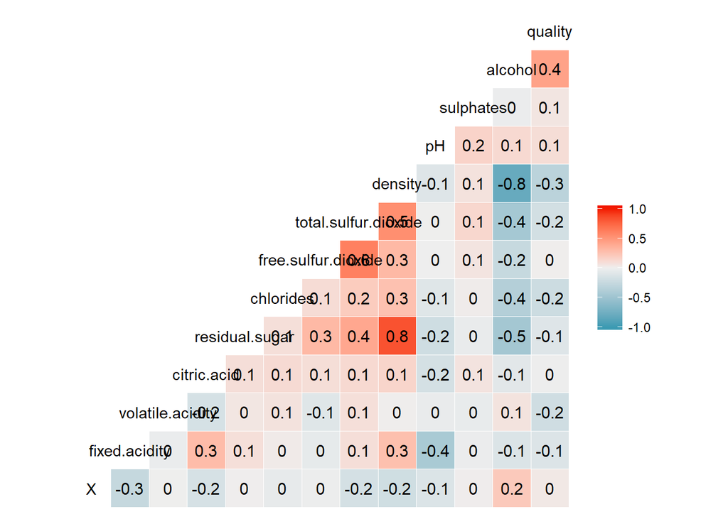

```r
ggcorr(wine_new, label = TRUE)
```

We can see strong positive correlation between residual sugar and density and medium positive correlations between total sulfur dioxide and density, free sulfur dioxide and total sulphur dioxide (this one is easily explained, as total sulphur dioxide contains free sulphur dioxide). Strong negative correlation is between density and alcohol, medium negative correlation is between residual sugar and alcohol. There is also correlation between alcohol and quality, it is about 0.4.

Let’s explore these some of these pairs in more details.

First of all, as we are interested in quality as and important output variable, we will explore it through categories with boxplots and frequency polygons

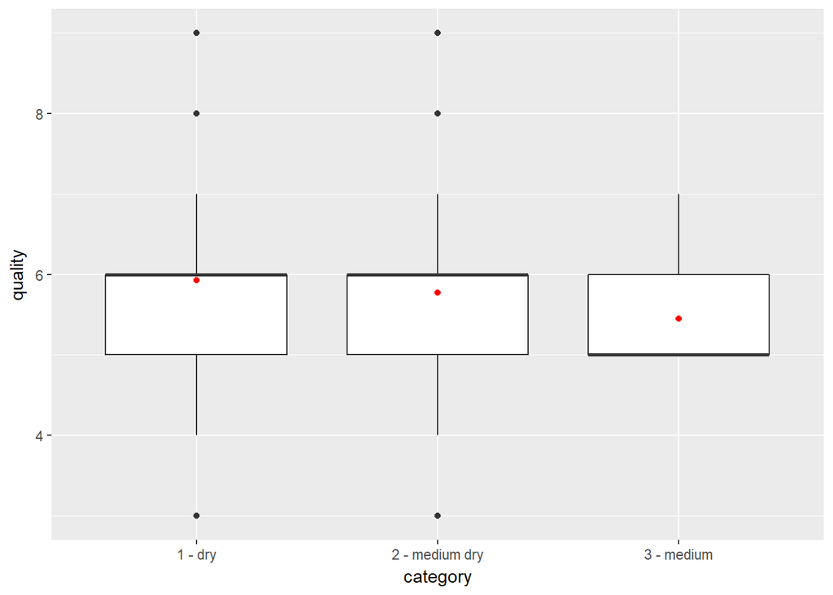

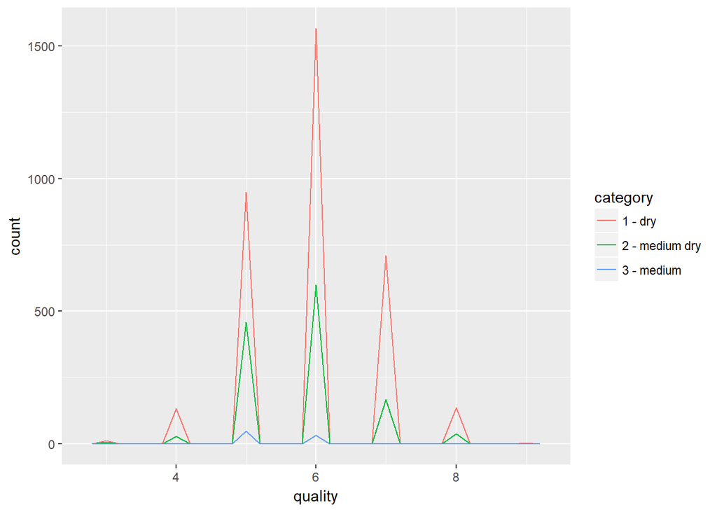

Explore the distribution of alcohol through quality, including conditional summaries. Also reduce overplotting with transparency.

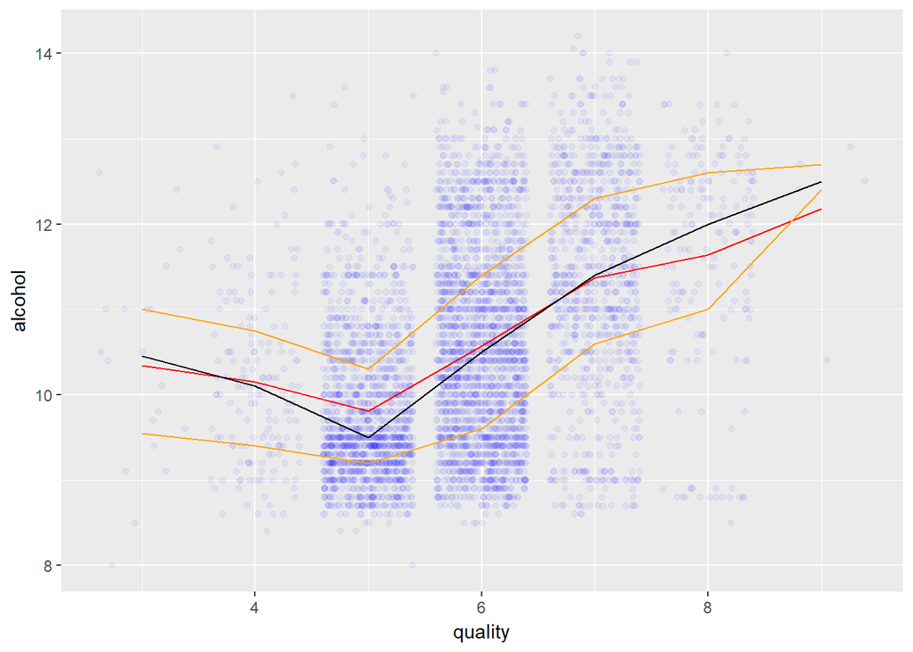

We can see a strong corellation on the most part of the plot, for quality 5 to 9. But more poor wines (quality 3 to 5) have almost stable alcohol levels, even with small decrease. Let’s change varibles between axes and add smoother.

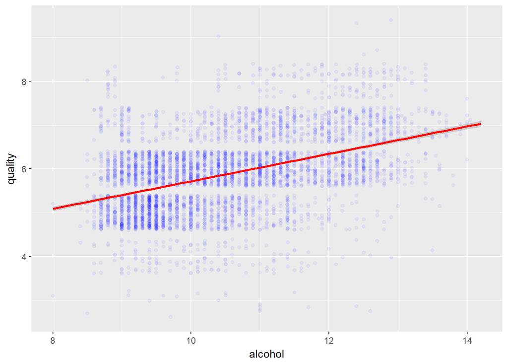

This plot shows that wines with higher alcohol have higher quality. We can check this also with the Pearson’s R

```
##
##  Pearson's product-moment correlation
##
## data:  wine_new$alcohol and wine_new$quality
## t = 33.856, df = 4895, p-value < 2.2e-16
## alternative hypothesis: true correlation is not equal to 0
## 95 percent confidence interval:
##  0.4126145 0.4580111
## sample estimates:
##       cor
## 0.4355897
```

Deffinitely, there is a positive correlation between alcohol and quality.

Now let’s see the distribution of alcohol depending on the category of wine.

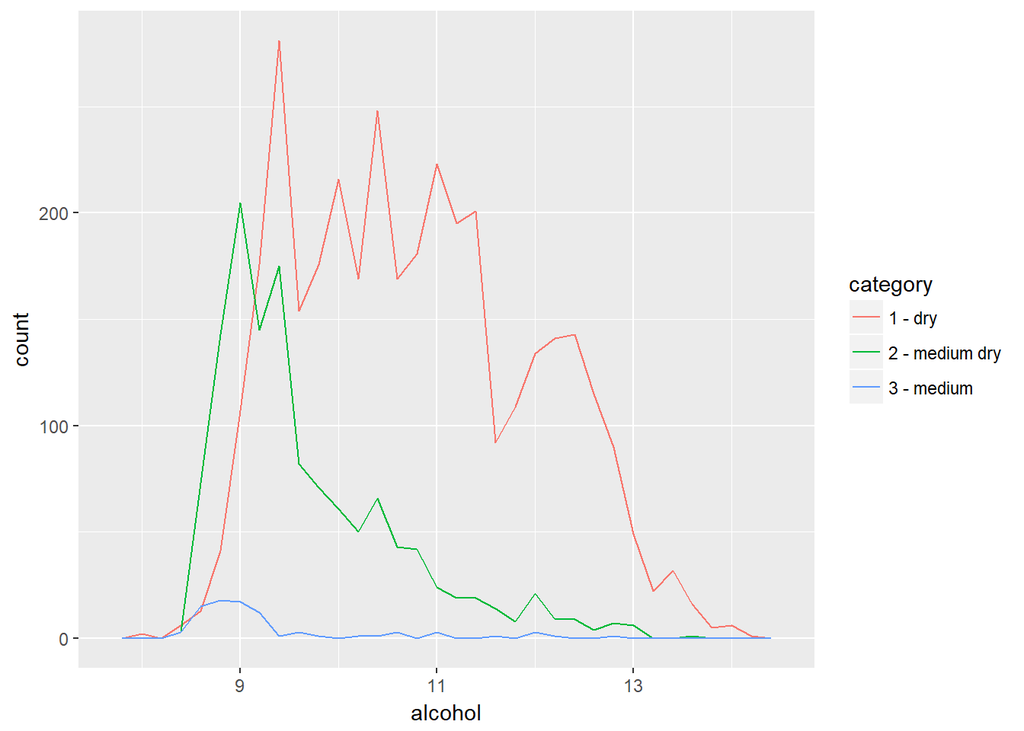

```
## wine_new$category: 1 - dry
##    Min. 1st Qu.  Median    Mean 3rd Qu.    Max.
##    8.00    9.90   10.70   10.83   11.70   14.20
## --------------------------------------------------------
## wine_new$category: 2 - medium dry
##    Min. 1st Qu.  Median    Mean 3rd Qu.    Max.
##   8.500   9.000   9.400   9.728  10.200  13.600
## --------------------------------------------------------
## wine_new$category: 3 - medium
##    Min. 1st Qu.  Median    Mean 3rd Qu.    Max.
##   8.500   8.800   9.000   9.352   9.300  12.800
```

It looks like dry wines has wider range of alcohol content. Medium dry and medium wines in our dataset tend to have lower alcohol content. Will explore relationship between alcohol and sugar content in later analisys.

Let’s see the relation between residual sugar and quality.

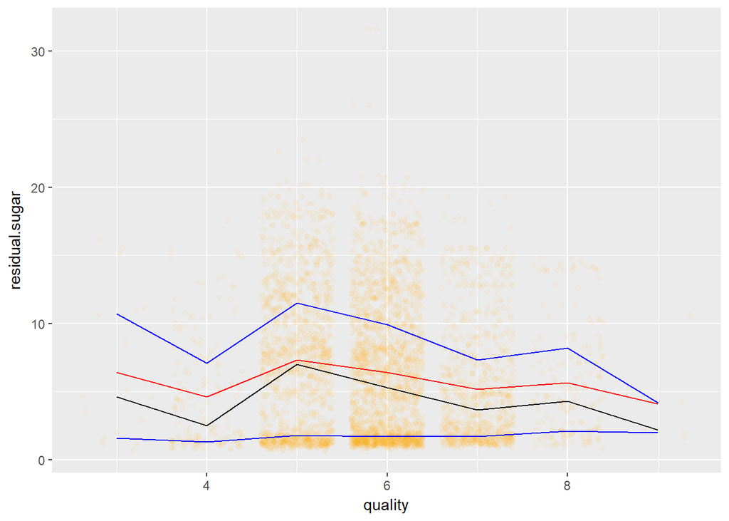

This plot shows no clear correlation. Let’s take a look also from other axis, as we did at our previous pair of variables

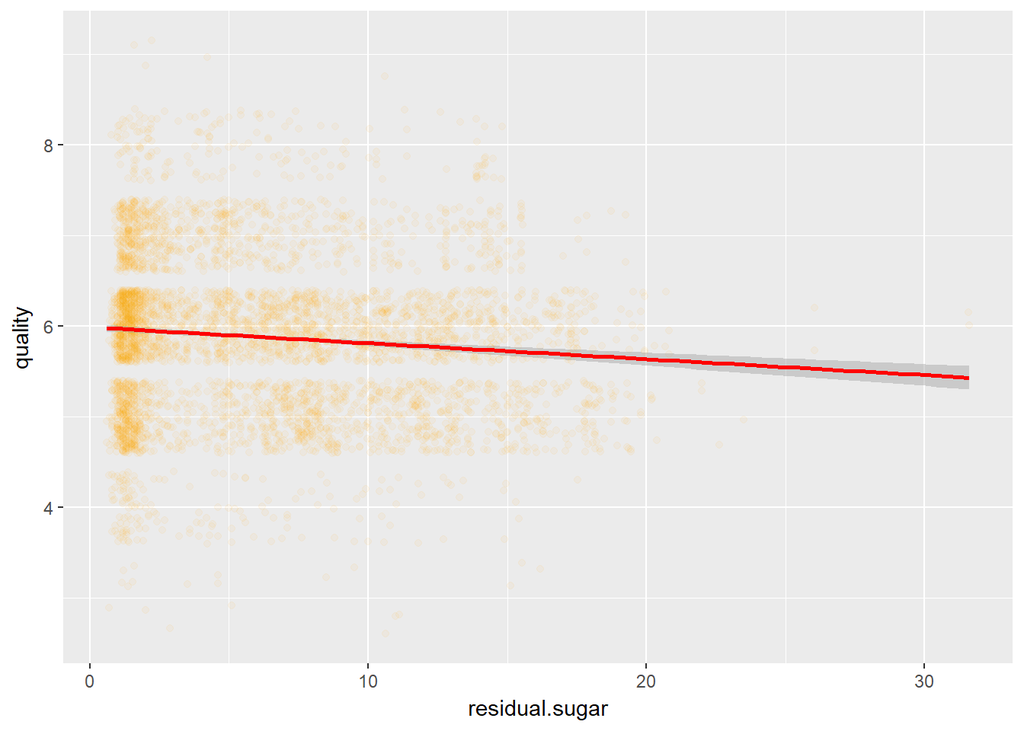

We can say, that these plots show the same distribution of values for different quality levels. Most of the wines of any quality have very low sugar levels and there are less wines with more sugars. Correlation between these two variable is very weak.

Finally, let’s explore relationship between alcohol and residual sugar.

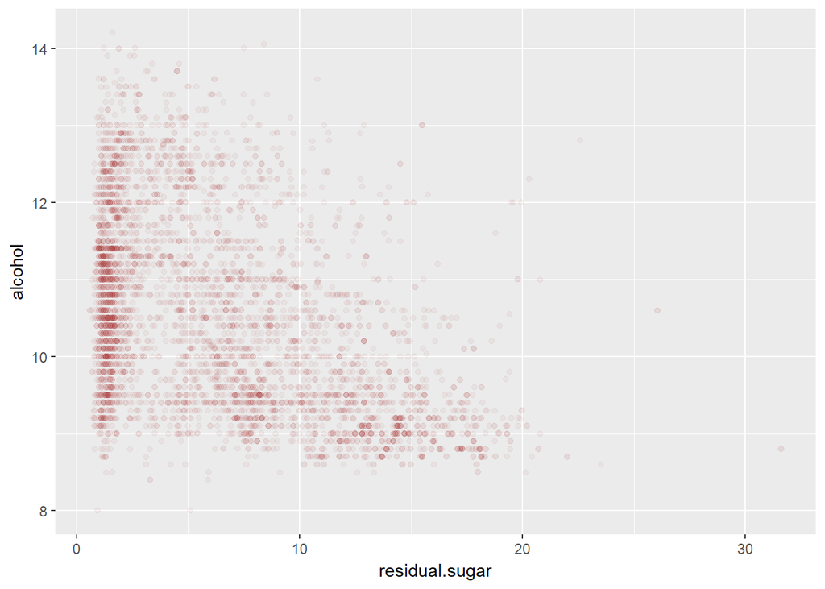

Surely, this is a non-linear correlation, in general we can notice, that wines with high alcohol content tend to have low sugars, and wines with a lot of sugar have low alcohol content. Let’s check if we can see a stronger relationship adding various transformations.

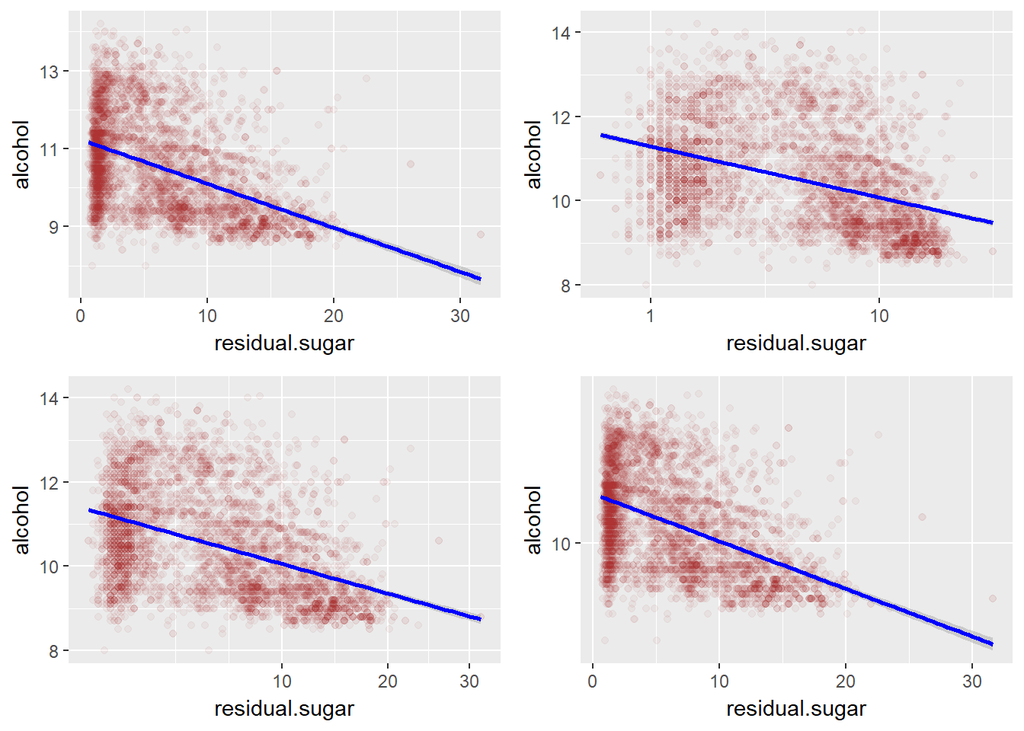

We can see non-linear negative correlation, but none of these scatterplots uncover any extra pattern. Also let’s count Pearson’s R to see the strength of the relationship.

```
##
##  Pearson's product-moment correlation
##
## data:  wine_new$residual.sugar and wine_new$alcohol
## t = -36.192, df = 4895, p-value < 2.2e-16
## alternative hypothesis: true correlation is not equal to 0
## 95 percent confidence interval:
##  -0.4812780 -0.4370779
## sample estimates:
##        cor
## -0.4594624
```

So, statistics confirms negative relationship with medium strength (-0.459)

Now let’s explore relationship between residual sugar and density

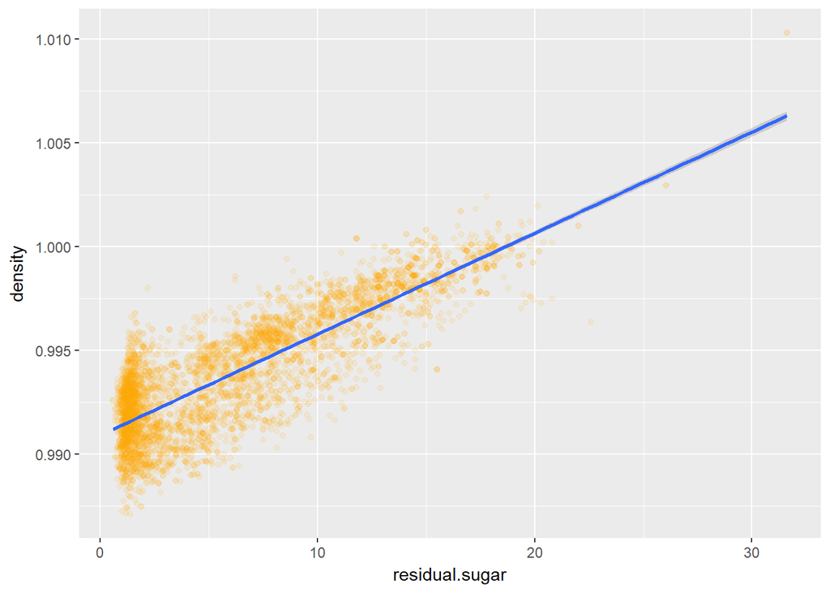

This visualization shows a positive correlation between residual sugar and density. Also we can see again that most of our wines are dry wines, with low level of sugar.

Finally, let’s explore relationship between density and quality.

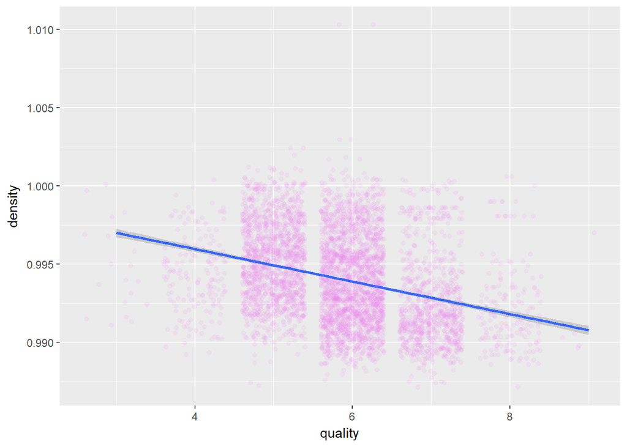

We can see a negative correlation, let’s count the Pearson’s R for this pair of variables.

```
##
##  Pearson's product-moment correlation
##
## data:  wine_new$density and wine_new$quality
## t = -23.212, df = 4895, p-value < 2.2e-16
## alternative hypothesis: true correlation is not equal to 0
## 95 percent confidence interval:
##  -0.3399086 -0.2894409
## sample estimates:
##        cor
## -0.3148973
```

Pearson’s R is -0.315. It is not a very strong correlation, but it is worth further investigation.

# Bivariate Analysis

### Talk about some of the relationships you observed in this part of the investigation. How did the feature(s) of interest vary with other features in the dataset?

My first interest was to see the relationships between pairs of 3 variables: alcohol, residual.sugar and quality. Analysis shows positive correlation between alcohol and quality, which I will continue to explore in the third part of the project. There were no significant relationship between quality and residual sugar. Also, negative correlation was found between residual sugar and alcohol.

### Did you observe any interesting relationships between the other features (not the main feature(s) of interest)?

I found a very high correlation between density and alcohol

### What was the strongest relationship you found?

The strongest relatioships are between density and alcohol (-0.8) and density and residual sugar (0.8).

# Multivariate Plots Section

First of all, let’s create scatterplot matrices for all the variables we are interested in in our analysis.

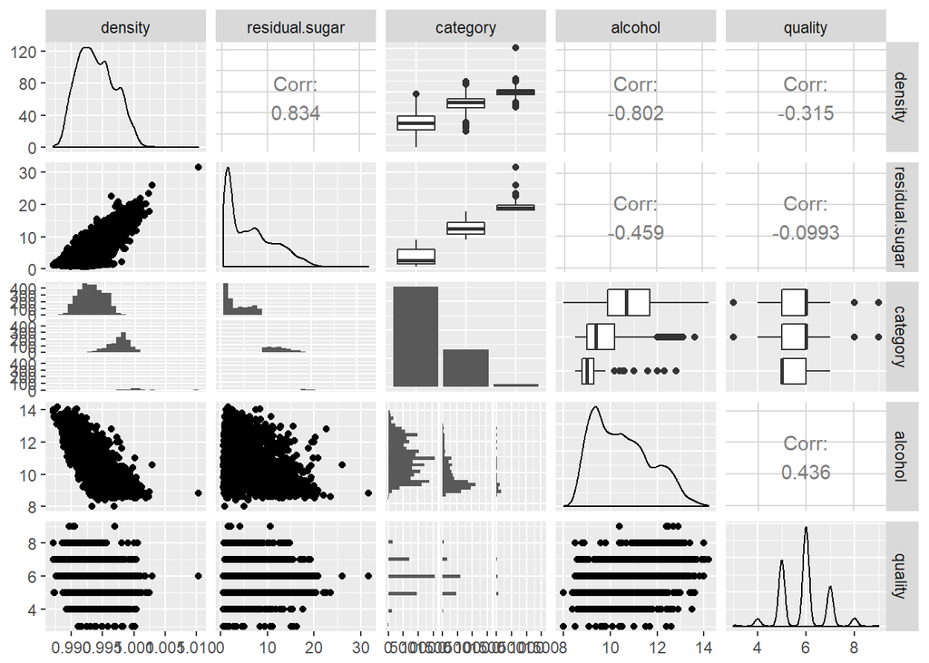

In the matrices we can see many details. Categorial variable ‘category’ gives us boxplot vizualizations and multiple histograms. Other variables have scatter plots. Also we can see more detailed correlation coefficients for different pairs of variables. As we know from previous analysis and now can see on the matrices, there are a strong positive correlation between density and residual sugar (0.834) and strong negative correlation between density and alcohol (-0.802). Alcohol and sugar, as considered before, have non-linear negative correlation. Alcohol and quality and correlated positively (0.436), the scatterplot shows that the correlation is weak.

First, let’s explore relation of alcohol, density and category of wine, as we already know that all these variables are correlated.

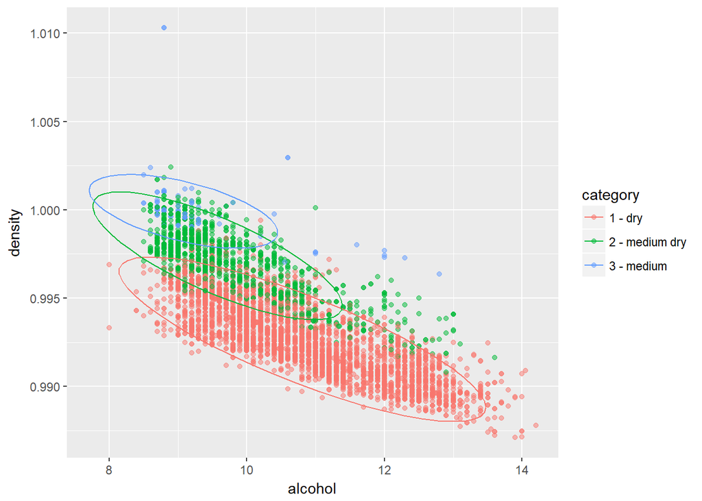

So, the scatterplot confirms the negative correlation between the alcohol and density for the whole dataset and for every category as well. Also we can see, that wines which are sweeter have higher density, for the same alcohol value.

Let’s also create multiple scatterplots to check, if this relationship between alcohol and density changes for quality of wine.

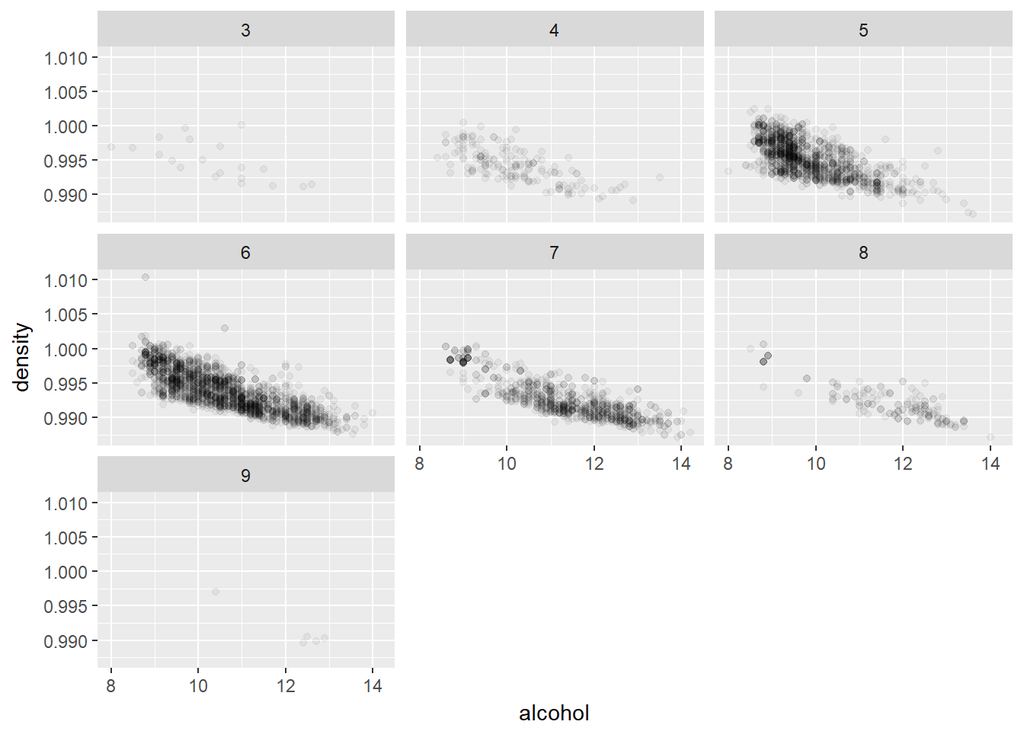

Some of the scatterplots have few observations, because very good and very poor wines are not many in our dataset, but all the scatterplots clearly show the same relationship between variables, so it is not corellated with the quality of wine.

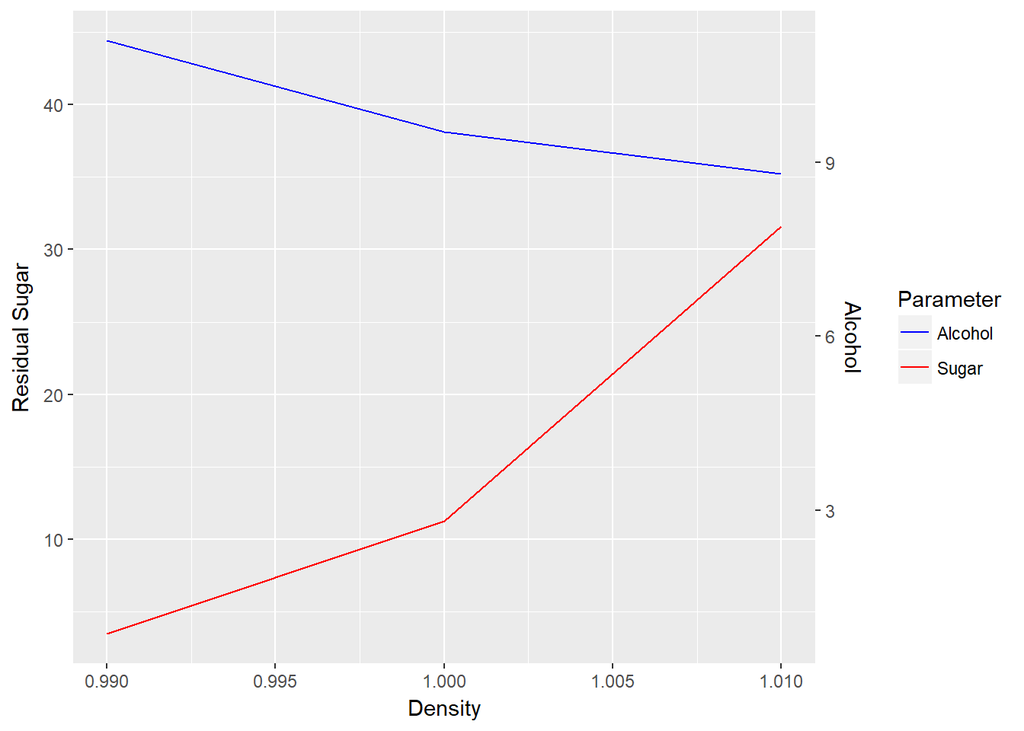

This plot shows the relation between alcohol, residual sugar and density. There is a positive correlation between density and residual sugar. Corellation between alcohol and density is negative. On the visualization we can see 2 almost straight lines, each one of them “breaks” at the same point, changing (slightly or more) the inclination. This point is the density of 1.00, the density of clear water. The wine with this density will have a mean alcohol of 9.5 and the mean residual sugar 12.

Let’s explore the relation between descrete variable quality and 2 continuous variables: alcohol and residual sugar, by creating boxplots.

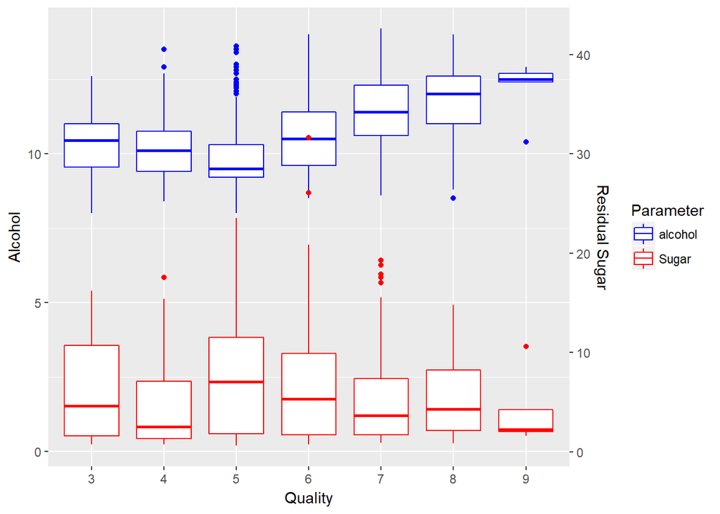

```r
# Adding 2 y-axis on the plot
# Transforming y-axe for sugar by /3, so lines create better visualization.
ggplot(wine_new, aes(x = factor (quality) )) +
  geom_boxplot(aes(y= alcohol, color = 'alcohol') ) +
  geom_boxplot(aes(y = residual.sugar/3, color = 'Sugar') ) +
  scale_y_continuous(sec.axis = sec_axis(~.*3, name = "Residual Sugar")) +
  scale_colour_manual(values = c("blue", "red")) +
  labs(y = "Alcohol", x = "Quality", colour = "Parameter")
```

As we can see, wines with low quality (3-4) do not have clear relationship with alcohol or sugar. One of the reasons for this can be actually a quality itself. If experts decided that these wines were bad, wine could be not balanced and have too little sugar (not good grapes), or have added sugar, or have added alcohol. Wines with average and above quality have visible trends. Wines with higher quality have less sugar and more alcohol.

# Multivariate Analysis

### Talk about some of the relationships you observed in this part of the investigation. Were there features that strengthened each other in terms of looking at your feature(s) of interest?

I observed some relationships between alcohol and density, alcohol and quality, alcohol and residual sugar and made multivariable plots to explore them in more details. Also I created scatterplot matrices to have a general view of relationships between variables of my interest.

### Were there any interesting or surprising interactions between features?

Figuring out the relationship between alcohol and density, I was surprised to see, that sweeteness of the wine has influence on it. For the same amount of alcohol more sweet wine will have higher density.

# Final Plots and Summary

### Plot One

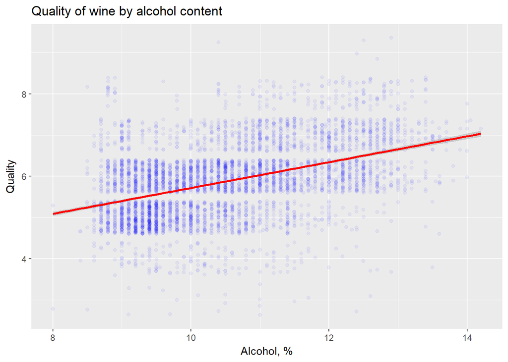

### Description One

This plot shows the relation between quality and alcohol. We see that wines with higher persentage of alcohol are more likely to have higher quality. Red smoother line is showing this tendention.

Alpha = 0.05 is used here to avoid overlapping, and jitter is used for the same reason, as quality variable is discrete. So we can also see distribution of wines in our dataset. Most of the wines have quality 5 and 6, less wines have quality 7, and much less wines have lower or higher quality.

Also we can see that almost all the wines contain 9 to 13% of alcohol, with the biggest part to be 9-11%, which is the most common alcohol level for white european wines.

### Plot Two

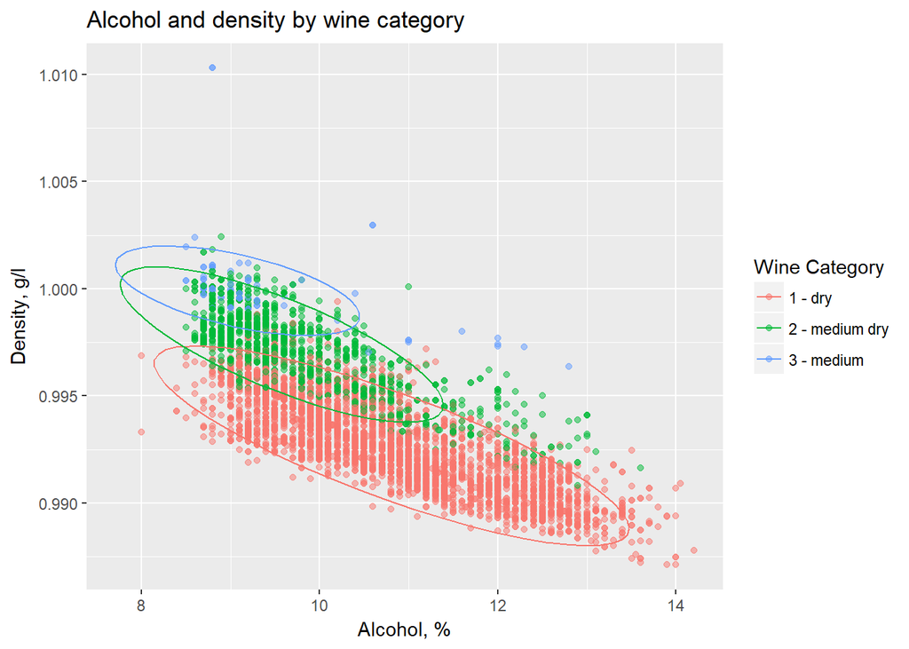

### Description Two

This plot shows relationship between density and alcohol. We can see negative correlation between these variables, which is explained by the nature of making alcohol drink. Density of water is 1.0 and density of clear alcohol is 0.783. So the higher volume alcohol has in the water-alcohol mix, the lower will be the density of this mix. Coloring the plot by wine category we also add the sugar content into this relationship. We can see, that general negative corellation is the same within every category, but the most interesting thing we see - that wines with the same alcohol content will have higher density if they are have more sugar. F.e. for alcohol content of 9% dry wines will have density approx 0.993 to 0.997, medium dry 0.996 to 1.001 and medium 0.998 to 1.002.

### Plot Three

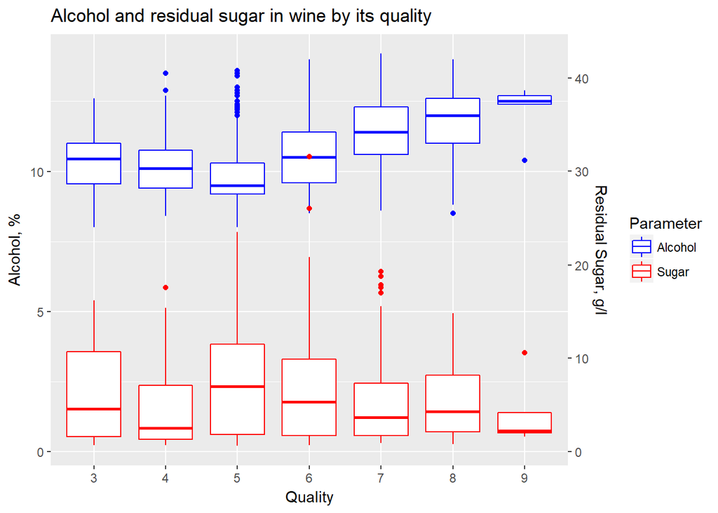

### Description Three

This plot shows the relation between quality and 2 values: residual.sugar and alcohol.

We can split visualization into 2 parts. First part - wines with low quality (3-4). They do not have clear relationship with alcohol or sugar. One of the reasons for this can be actually a quality itself. If experts decided that these wines were bad, wine could be not balanced and have too little sugar (not good grapes), or have added sugar, or have added alcohol. Second part - Wines with average and high quality (5-9). Here we can see clear positive correlation for alcohol and negative correlation for sugar. Wines with higher quality have less sugar and more alcohol.

# Reflection

During the analysis I made I experienced several important moments.

It is very important to explore individual variables and their distribution before exploring relationships.

If a dataset is not big enough, there may be too few observations in some parts, so the exploration will not be reliable. F.e. in my dataset we had only one observation for sweet wine. Deffinitely, you can’t rely on it for making decisions about category.

Sometimes the visualizations you choose may not reflect the correlation (maybe it is a wrong type of plot or wrong binwidth). So it is important not to make decision from the first plot, but to try different techniques - reduce overplotting, transform variables, and to apply condition summaries. Statistics matter.

The dataset may not always allow us to make a model, because there can be other variables, which influence the output, but they are not in your dataset. The quality of wine depends very highly on the quality of grapes, on the type of grapes and on the age of the wine. We knew nothing about this. It would be nice, if we could have some of this information to explore it and to try to make a model depending on it.

I had some struggles. It is not easy to find the correct way to visualize the data. Making wrong plot may lead to mistakes in interpretation of relationships. In our dataset I had to work with different types of data (categorical, discrete, continuous), each of them needed special approach.

But I was happy when I found the trends and was able to interpretate them. It is nice to start with exploring distribution and then to end with multivariable analysis. It was interesting to see the relationship between alcohol and quality or explore different variables through categories, which I decided to create.